# gains_incrémentiels

**Made By DAHOU RENAUD L. Data Scientist in Benin**

- Whatsapp: +22967927952
- Email: dahou.r@yahoo.com

## **Répertoire de travail**

```python
from google.colab import drive
drive.mount('/content/drive/')
```

```python
import os
os.chdir("/content/drive/My Drive/DATASCIENCE/Projet/Modèles_réponse_marché")
```

```python
!jupyter nbconvert --to html gains_incrémentiels.ipynb
```

```
[NbConvertApp] Converting notebook gains_incrémentiels.ipynb to html
[NbConvertApp] Writing 839575 bytes to gains_incrémentiels.html
```

## **Importation des librairies python**

```python
from datetime import datetime, timedelta,date
import pandas as pd
%matplotlib inline
from sklearn.metrics import classification_report,confusion_matrix
import matplotlib.pyplot as plt
import numpy as np
import seaborn as sns
from __future__ import division
from sklearn.cluster import KMeans

import sklearn
import xgboost as xgb
from sklearn.model_selection import KFold, cross_val_score, train_test_split

import warnings
warnings.filterwarnings('ignore')
```

# **EDA Prédire les gains incrémentiels des campagnes promotionnelles**

Ce projet se concentre sur comment augmenter nos ventes? Si nous faisons une remise aujourd'hui, à combien de transactions supplémentaires devrions-nous nous attendre? pour le Marketing B2C & BtoB en utilisant Python.

La segmentation des clients et les tests A / B nous permettent d'essayer de nombreuses idées différentes pour générer des ventes. C'est l'un des éléments constitutifs du Growth Hacking. Nous avons besoins d'idée et d'expérimenter en permanence pour trouver des opportunités de croissance.

La répartition des clients auxquels nous allons envoyer l'offre en groupes de test et de contrôle nous aide à calculer les gains incrémentiels.

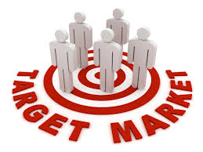

[figure not shown]

Dans cette configuration, le groupe cible a été divisé en trois groupes pour trouver une réponse aux questions ci-dessous:

- 1- Est-ce que donner une offre augmente la conversion?
- 2- Si oui, quel type d'offre fonctionne le mieux? Remise ou acheter un en obtenir un?

En supposant que les résultats sont statistiquement significatifs, la remise (groupe A) semble la meilleure car elle a augmenté la conversion de 3% par rapport au groupe témoin et a apporté 1% de conversion supplémentaire contre Buy One Get One.

Bien sûr, dans le monde réel, c'est beaucoup plus compliqué. Certaines offres fonctionnent mieux sur des segments spécifiques. Nous devons donc créer un portefeuille d'offres pour les segments sélectionnés. De plus, Nous ne pouvons pas compter sur la conversion comme seul critère de réussite. Il y a toujours un compromis entre les coûts. Généralement, alors que les taux de conversion augmentent, les coûts augmentent également. C'est pourquoi, parfois, nous devons sélectionner une offre économique, mais qui génère moins de conversion.

Maintenant, nous savons quelle offre a bien fonctionné par rapport aux autres grâce à l'expérience. Mais qu'en est-il de le prédire? Si nous prédisons l'effet de l'offre, nous pouvons facilement maximiser nos transactions et avoir une prévision du coût. Les modèles de réponse du marché nous aident à construire ce cadre. Mais il y a plus d'une façon de le faire. Nous pouvons les regrouper en deux:

- 1- Si nous n'avons pas de groupe témoins (imaginons que nous avons fait une promotion ouverte à tout le monde et que nous l'avons annoncé sur les réseaux sociaux), alors nous ne pouvons pas calculer l'incrémentalité. Pour ce genre de situation, mieux vaut construire un modèle de régression qui prédit les ventes globales. L'hypothèse précédente sera que le modèle fournira des chiffres de vente plus élevés pour les jours de promotion.

Pour créer ce type de modèle, notre ensemble de données doit inclure les numéros de vente des jours promotionnels et non promotionnels afin que le modèle d'apprentissage automatique puisse calculer l'incrémentalité.

- 2- Si nous avons un groupe de contrôle, nous pouvons créer le modèle de réponse en fonction du segment ou du niveau individuel. Pour les deux, l'hypothèse c'est la même.
  - Faire une offre devrait augmenter la probabilité de conversion. *La hausse de la probabilité de conversion des individus nous apportera la conversion incrémentale.

Nous utiliserons [cet ensemble de données marketing](https://blog.minethatdata.com/2008/03/minethatdata-e-mail-analytics-and-data.html) pour notre analyse Mais j'ai fait quelques modifications pour le rendre plus pertinent pour notre cas

Nos 8 premières colonnes fournissent des données au niveau individuel et la colonne de conversion est notre étiquette pour prédire:

- recency: mois depuis le dernier achat
- history: valeur en $ des achats historiques
- used_discount/used_bogo: indique si le client a utilisé une remise ou en a acheté une avant
- zip_code: classe du code postal comme Suburban / Urban / Rural
- is_referral: indique si le client a été acquis à partir du canal de référence
- channel: canaux que le client utilise, Téléphone / Web / Multicanal
- offer: les offres envoyées aux clients, Remise / Mais on en a une / Pas d'offre

```python
df_data = pd.read_csv('data.csv')
df_data
```

|  | recency | history | used_discount | used_bogo | zip_code | is_referral | channel | offer | conversion |
| --- | --- | --- | --- | --- | --- | --- | --- | --- | --- |
| 0 | 10 | 142.44 | 1 | 0 | Surburban | 0 | Phone | Buy One Get One | 0 |
| 1 | 6 | 329.08 | 1 | 1 | Rural | 1 | Web | No Offer | 0 |
| 2 | 7 | 180.65 | 0 | 1 | Surburban | 1 | Web | Buy One Get One | 0 |
| 3 | 9 | 675.83 | 1 | 0 | Rural | 1 | Web | Discount | 0 |
| 4 | 2 | 45.34 | 1 | 0 | Urban | 0 | Web | Buy One Get One | 0 |
| ... | ... | ... | ... | ... | ... | ... | ... | ... | ... |
| 63995 | 10 | 105.54 | 1 | 0 | Urban | 0 | Web | Discount | 0 |
| 63996 | 5 | 38.91 | 0 | 1 | Urban | 1 | Phone | Discount | 0 |
| 63997 | 6 | 29.99 | 1 | 0 | Urban | 1 | Phone | Discount | 0 |
| 63998 | 1 | 552.94 | 1 | 0 | Surburban | 1 | Multichannel | Buy One Get One | 0 |
| 63999 | 1 | 472.82 | 0 | 1 | Surburban | 0 | Web | Discount | 0 |

64000 rows × 9 columns

```python
df_data.shape
```

```
(64000, 9)
```

```python
df_data.info()
```

```
<class 'pandas.core.frame.DataFrame'>
RangeIndex: 64000 entries, 0 to 63999
Data columns (total 9 columns):
recency          64000 non-null int64
history          64000 non-null float64
used_discount    64000 non-null int64
used_bogo        64000 non-null int64
zip_code         64000 non-null object
is_referral      64000 non-null int64
channel          64000 non-null object
offer            64000 non-null object
conversion       64000 non-null int64
dtypes: float64(1), int64(5), object(3)
memory usage: 4.4+ MB
```

```python
df_data.conversion.mean()
```

```
0.14678125
```

Nous allons construire un modèle de classification binaire pour évaluer la probabilité de conversion de tous les clients. Pour ce faire, nous allons suivre les étapes ci-dessous:

- Construire la formule de l'élévation(upflit)
- Analyse exploratoire des données (EDA) et ingénierie des fonctionnalités
- Scoring des probabilités de conversion
- Observer les résultats sur l'ensemble de test

### **Formule Uplift**

Tout d'abord, nous devons créer une fonction qui calcule notre upflit. Pour rester simple, nous supposerons que chaque conversion signifie 1 commande et la valeur moyenne d'une commande est de 25 $.

Nous allons calculer trois types de upflit:

```python
#Construisons notre fonction calc_uplift :

def calc_uplift(df):
    #assigning 25$ to the average order value
    avg_order_value = 25

    #calculate conversions for each offer type
    base_conv = df[df.offer == 'No Offer']['conversion'].mean()
    disc_conv = df[df.offer == 'Discount']['conversion'].mean()
    bogo_conv = df[df.offer == 'Buy One Get One']['conversion'].mean()

    #calculate conversion uplift for discount and bogo
    disc_conv_uplift = disc_conv - base_conv
    bogo_conv_uplift = bogo_conv - base_conv

    #calculate order uplift
    disc_order_uplift = disc_conv_uplift * len(df[df.offer == 'Discount']['conversion'])
    bogo_order_uplift = bogo_conv_uplift * len(df[df.offer == 'Buy One Get One']['conversion'])

    #calculate revenue uplift
    disc_rev_uplift = disc_order_uplift * avg_order_value
    bogo_rev_uplift = bogo_order_uplift * avg_order_value


    print('Discount Conversion Uplift: {0}%'.format(np.round(disc_conv_uplift*100,2)))
    print('Discount Order Uplift: {0}'.format(np.round(disc_order_uplift,2)))
    print('Discount Revenue Uplift: ${0}\n'.format(np.round(disc_rev_uplift,2)))

    print('-------------- \n')

    print('BOGO Conversion Uplift: {0}%'.format(np.round(bogo_conv_uplift*100,2)))
    print('BOGO Order Uplift: {0}'.format(np.round(bogo_order_uplift,2)))
    print('BOGO Revenue Uplift: ${0}'.format(np.round(bogo_rev_uplift,2)))
```

Si nous appliquons cette fonction à notre base de données, nous verrons les résultats ci-dessous:

```python
calc_uplift(df_data)
```

```
Discount Conversion Uplift: 7.66%
Discount Order Uplift: 1631.89
Discount Revenue Uplift: $40797.35

--------------

BOGO Conversion Uplift: 4.52%
BOGO Order Uplift: 967.4
BOGO Revenue Uplift: $24185.01
```

La remise (Discount) semble être une meilleure option si nous voulons obtenir plus de conversion. Il apporte une hausse de 7,6% par rapport aux clients qui n'ont reçu aucune offre. BOGO (Buy One Get One) a également une hausse de 4,5% .

## **EDA et ingénierie des fonctionnalités**

## **Récence**

Idéalement, la conversion devrait diminuer tandis que la récence augmente, car les clients inactifs sont moins susceptibles d'acheter à nouveau:

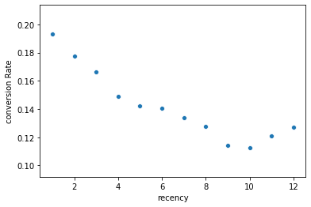

```python
ax = sns.scatterplot(x="recency", y="conversion", data=df_data.groupby('recency').conversion.mean().reset_index())
plt.ylabel('conversion Rate')
```

Nous allons créer un cluster recency et observer son impact. Appliquons le clustering k-means pour définir les groupes significatifs de la récence:

```python
def order_cluster(cluster_field_name, target_field_name,df,ascending):
    new_cluster_field_name = 'new_' + cluster_field_name
    df_new = df.groupby(cluster_field_name)[target_field_name].mean().reset_index()
    df_new = df_new.sort_values(by=target_field_name,ascending=ascending).reset_index(drop=True)
    df_new['index'] = df_new.index
    df_final = pd.merge(df,df_new[[cluster_field_name,'index']], on=cluster_field_name)
    df_final = df_final.drop([cluster_field_name],axis=1)
    df_final = df_final.rename(columns={"index":cluster_field_name})
    return df_final
```

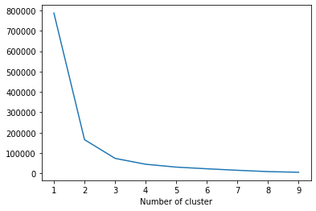

```python
####################recency
sse={}
df_cluster = df_data[['recency']]
for k in range(1, 10):
    kmeans = KMeans(n_clusters=k, max_iter=1000).fit(df_cluster)
    df_cluster["clusters"] = kmeans.labels_
    sse[k] = kmeans.inertia_
plt.figure()
plt.plot(list(sse.keys()), list(sse.values()))
plt.xlabel("Number of cluster")
plt.show()
```

#### **Taux de conversion par groupe de récence**

```python
kmeans = KMeans(n_clusters=3)
kmeans.fit(df_data[['recency']])
df_data['recencyCluster'] = kmeans.predict(df_data[['recency']])

df_data = order_cluster('recencyCluster', 'recency',df_data,True)
df_data.groupby('recencyCluster').recency.describe()
```

| recencyCluster | count | mean | std | min | 25% | 50% | 75% | max |
| --- | --- | --- | --- | --- | --- | --- | --- | --- |
| 0 | 22393.0 | 1.863886 | 0.803071 | 1.0 | 1.0 | 2.0 | 3.0 | 3.0 |
| 1 | 18270.0 | 5.420580 | 1.116221 | 4.0 | 4.0 | 5.0 | 6.0 | 7.0 |
| 2 | 23337.0 | 9.774478 | 1.172222 | 8.0 | 9.0 | 10.0 | 11.0 | 12.0 |

Nous avons 3 grappes avec 1,86, 5,42 et 9,77 comme récence moyenne.

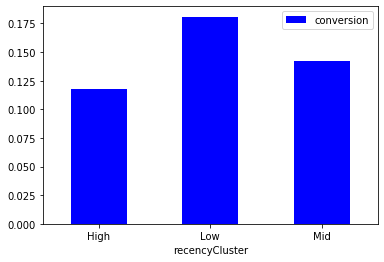

```python
df_data['recencyCluster'] = df_data["recencyCluster"].replace({0:'Low',1:'Mid',2:'High'})

data=df_data.groupby('recencyCluster').conversion.mean().reset_index()
ax = data.plot.bar(x='recencyCluster', y='conversion', rot=0, color='blue')
```

## **historiques**

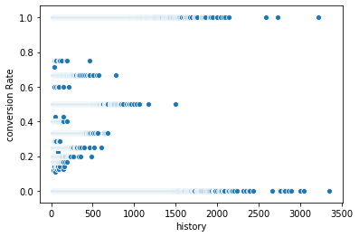

```python
ax = sns.scatterplot(x="history", y="conversion", data=df_data.groupby('history').conversion.mean().reset_index())
plt.ylabel('conversion Rate')
```

il n'y a aucune tendance entre le taux de conversion et les historiques

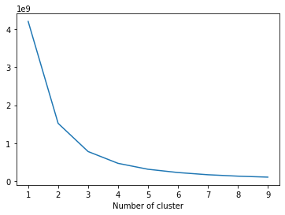

```python
####################history
sse={}
df_cluster = df_data[['history']]
for k in range(1, 10):
    kmeans = KMeans(n_clusters=k, max_iter=1000).fit(df_cluster)
    df_cluster["clusters"] = kmeans.labels_
    sse[k] = kmeans.inertia_
plt.figure()
plt.plot(list(sse.keys()), list(sse.values()))
plt.xlabel("Number of cluster")
plt.show()
```

```python
kmeans = KMeans(n_clusters=3)
kmeans.fit(df_data[['history']])
df_data['historyCluster'] = kmeans.predict(df_data[['history']])

df_data = order_cluster('historyCluster', 'history',df_data,True)
df_data.groupby('historyCluster').history.describe()
```

| historyCluster | count | mean | std | min | 25% | 50% | 75% | max |
| --- | --- | --- | --- | --- | --- | --- | --- | --- |
| 0 | 43715.0 | 109.266653 | 70.766796 | 29.99 | 42.2450 | 93.840 | 164.3 | 266.89 |
| 1 | 16620.0 | 424.817395 | 118.496014 | 266.92 | 323.8175 | 398.725 | 508.3 | 711.21 |
| 2 | 3665.0 | 997.660333 | 299.525007 | 711.30 | 789.6800 | 898.090 | 1111.6 | 3345.93 |

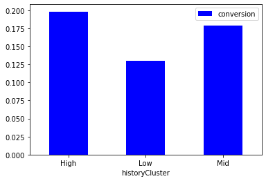

```python
df_data['historyCluster'] = df_data["historyCluster"].replace({0:'Low',1:'Mid',2:'High'})

data=df_data.groupby('historyCluster').conversion.mean().reset_index()
ax = data.plot.bar(x='historyCluster', y='conversion', rot=0, color='blue')
```

Les clients dont la valeur en dollars est plus élevée sont plus susceptibles d'être convertir.

### **Vue d'ensemble des clusters et du tracé par rapport à la conversion:**

```python
df_data = order_cluster('historyCluster', 'history',df_data,True)
df_data.groupby('historyCluster').agg({'history':['mean','min','max'], 'conversion':['count', 'mean']})
```

| historyCluster | history mean | history min | history max | conversion count | conversion mean |
| --- | --- | --- | --- | --- | --- |
| 0 | 109.266653 | 29.99 | 266.89 | 43715 | 0.130299 |
| 1 | 424.817395 | 266.92 | 711.21 | 16620 | 0.178821 |
| 2 | 997.660333 | 711.30 | 3345.93 | 3665 | 0.198090 |

```python
df_data = order_cluster('recencyCluster', 'recency',df_data,True)
df_data.groupby('recencyCluster').agg({'recency':['mean','min','max'], 'conversion':['count', 'mean']})
```

| recencyCluster | recency mean | recency min | recency max | conversion count | conversion mean |
| --- | --- | --- | --- | --- | --- |
| 0 | 1.863886 | 1 | 3 | 22393 | 0.180860 |
| 1 | 5.420580 | 4 | 7 | 18270 | 0.141872 |
| 2 | 9.774478 | 8 | 12 | 23337 | 0.117924 |

```python
df_data.groupby(['channel','offer']).agg({'conversion':'mean'})
```

| channel | offer | conversion |
| --- | --- | --- |
| Multichannel | Buy One Get One | 0.175649 |
|  | Discount | 0.211486 |
|  | No Offer | 0.128550 |
| Phone | Buy One Get One | 0.131796 |
|  | Discount | 0.162771 |
|  | No Offer | 0.087166 |
| Web | Buy One Get One | 0.164529 |
|  | Discount | 0.194415 |
|  | No Offer | 0.118852 |

## **Discount & BOGO**

Les clients, qui ont utilisé les deux offres auparavant, ont le taux de conversion le plus élevé.

En utilisant le bloc de code ci-dessous, nous visualisons facilement à quoi ressemble le taux de conversion pour chaque valeur:

```python
def category_plot(df_src, df_by, h_v='h'):
    frequency_table(df_src)
    fig, ax = plt.subplots(1,2,figsize=(10,5))
    ax[1] = sns.countplot(x=df_src, hue=df_by, ax=ax[1], palette="Set3")
    ax[1].set(xlabel=df_src.name, ylabel=df_by.name, title = df_src.name + ' vs ' + df_by.name + ' plot')
    values = df_src.value_counts(normalize=True)* 100
    ax[0] = sns.countplot(x=df_src, palette='Set3', ax=ax[0])
    ax[0].set(xlabel=df_src.name, ylabel = 'Count', title= 'Frequency Plot')
    if(h_v == 'v'):
        ax[0].set_xticklabels(ax[0].get_xticklabels(), rotation=45)
        ax[1].set_xticklabels(ax[1].get_xticklabels(), rotation=45)

    plt.show()
```

```python
def get_percent(value, total, round_number = 2):
    return round(100 * value / total, round_number)
```

```python
def frequency_table(df,with_percent=True, with_margins=False):
    freq_df = pd.crosstab(index=df, columns="count", margins=with_margins).reset_index()
    if with_percent:
        freq_df['percent(%)'] = get_percent(freq_df['count'] , df.shape[0])
    print(freq_df)
```

```
col_0  used_discount  count  percent(%)
0                  0  28734        44.9
1                  1  35266        55.1
```

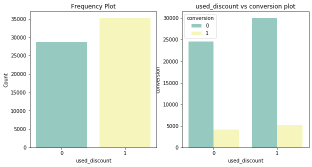

```python
# univariant analyis on MultipleLines
category_plot(df_data.used_discount,df_data.conversion)
```

```python
df_data.groupby(['used_discount']).agg({'conversion':'mean'})
```

| used_discount | conversion |
| --- | --- |
| 0 | 0.144150 |
| 1 | 0.148925 |

```
col_0  used_bogo  count  percent(%)
0              0  28818       45.03
1              1  35182       54.97
```

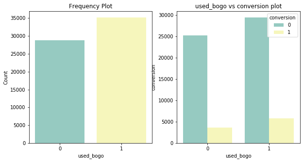

```python
# univariant analyis on MultipleLines
category_plot(df_data.used_bogo,df_data.conversion)
```

```python
df_data.groupby(['used_bogo']).agg({'conversion':'mean'})
```

| used_bogo | conversion |
| --- | --- |
| 0 | 0.126449 |
| 1 | 0.163436 |

## **Code postal**

Le rural montre une meilleure conversion par rapport aux autres:

```
col_0   zip_code  count  percent(%)
0          Rural   9563       14.94
1      Surburban  28776       44.96
2          Urban  25661       40.10
```

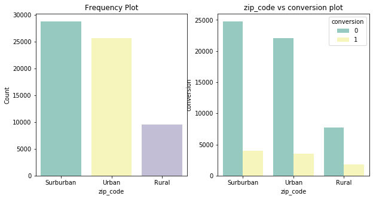

```python
# univariant analyis on MultipleLines
category_plot(df_data.zip_code,df_data.conversion)
```

```python
df_data.groupby(['zip_code']).agg({'conversion':'mean'})
```

| zip_code | conversion |
| --- | --- |
| Rural | 0.188121 |
| Surburban | 0.139943 |
| Urban | 0.139044 |

## **Référence**

Comme nous le voyons ci-dessous, les clients du canal de référence ont un taux de conversion inférieur:

```
col_0  is_referral  count  percent(%)
0                0  31856       49.78
1                1  32144       50.22
```

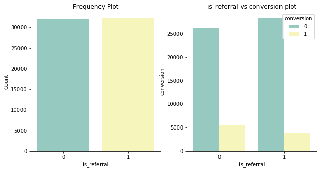

```python
# univariant analyis on MultipleLines
category_plot(df_data.is_referral,df_data.conversion)
```

```python
df_data.groupby(['is_referral']).agg({'conversion':'mean'})
```

| is_referral | conversion |
| --- | --- |
| 0 | 0.173060 |
| 1 | 0.120738 |

## **Canaux**

Le multicanal montre un taux de conversion plus élevé que prévu. L'utilisation de plusieurs canaux est un indicateur d'un engagement élevé.

```
col_0       channel  count  percent(%)
0      Multichannel   7762       12.13
1             Phone  28021       43.78
2               Web  28217       44.09
```

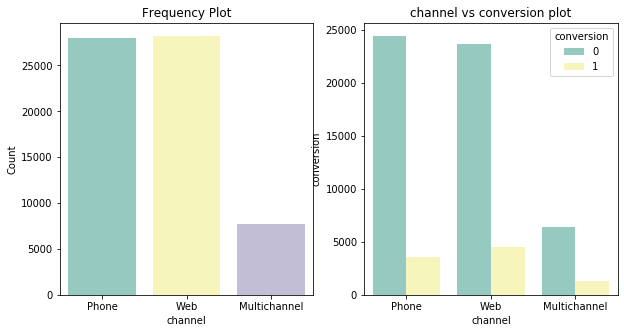

```python
# univariant analyis on MultipleLines
category_plot(df_data.channel,df_data.conversion)
```

```python
df_data.groupby(['channel']).agg({'conversion':'mean'})
```

| channel | conversion |
| --- | --- |
| Multichannel | 0.171734 |
| Phone | 0.127155 |
| Web | 0.159407 |

## **Type d'offre**

```
col_0            offer  count  percent(%)
0      Buy One Get One  21387       33.42
1             Discount  21307       33.29
2             No Offer  21306       33.29
```

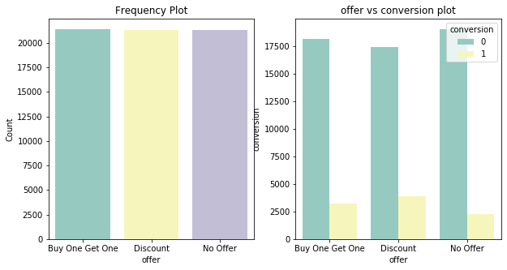

```python
# univariant analyis on MultipleLines
category_plot(df_data.offer,df_data.conversion)
```

```python
df_data.groupby(['offer']).agg({'conversion':'mean'})
```

| offer | conversion |
| --- | --- |
| Buy One Get One | 0.151400 |
| Discount | 0.182757 |
| No Offer | 0.106167 |

Les clients qui bénéficient d'offres de réduction affichent une conversion de ~ 18%, alors qu'elle est de ~ 15% pour BOGO. Si les clients n'obtiennent pas d'offre, leur taux de conversion baisse de ~ 4%.

# **Machine Learning Model**

Nous appliquerons .get_dummies () pour convertir les colonnes catégorielles en colonnes numériques:

```python
df_model = df_data.copy()
df_model = pd.get_dummies(df_model)
```

```python
df_model.head()
```

|  | recency | history | used_discount | used_bogo | is_referral | conversion | historyCluster | recencyCluster | zip_code_Rural | zip_code_Surburban | zip_code_Urban | channel_Multichannel | channel_Phone | channel_Web | offer_Buy One Get One | offer_Discount | offer_No Offer |
| --- | --- | --- | --- | --- | --- | --- | --- | --- | --- | --- | --- | --- | --- | --- | --- | --- | --- |
| 0 | 10 | 142.44 | 1 | 0 | 0 | 0 | 0 | 2 | 0 | 1 | 0 | 0 | 1 | 0 | 1 | 0 | 0 |
| 1 | 9 | 46.42 | 0 | 1 | 0 | 0 | 0 | 2 | 0 | 0 | 1 | 0 | 1 | 0 | 1 | 0 | 0 |
| 2 | 10 | 32.84 | 0 | 1 | 1 | 0 | 0 | 2 | 0 | 0 | 1 | 0 | 0 | 1 | 1 | 0 | 0 |
| 3 | 9 | 112.35 | 1 | 0 | 0 | 0 | 0 | 2 | 1 | 0 | 0 | 0 | 0 | 1 | 0 | 1 | 0 |
| 4 | 11 | 219.04 | 1 | 1 | 0 | 0 | 0 | 2 | 0 | 1 | 0 | 0 | 1 | 0 | 0 | 1 | 0 |

```python
#create feature set and labels
X = df_model.drop(['conversion'],axis=1)
y = df_model.conversion
```

Création de jeux de train et de test:

```python
X_train, X_test, y_train, y_test = train_test_split(X, y, test_size=0.2, random_state=56)
```

Nous ajusterons le modèle et obtiendrons les probabilités de conversion. La fonction predit_proba () de notre modèle attribue une probabilité pour chaque ligne:

```python
xgb_model = xgb.XGBClassifier().fit(X_train, y_train)
y_pred=xgb_model.predict(X_test)
print(classification_report(y_test, y_pred))
```

```
              precision    recall  f1-score   support

           0       0.85      1.00      0.92     10927
           1       0.00      0.00      0.00      1873

    accuracy                           0.85     12800
   macro avg       0.43      0.50      0.46     12800
weighted avg       0.73      0.85      0.79     12800
```

```python
X_test['proba'] = xgb_model.predict_proba(X_test)[:,1]
X_test.head(5)
```

|  | recency | history | used_discount | used_bogo | is_referral | historyCluster | recencyCluster | zip_code_Rural | zip_code_Surburban | zip_code_Urban | channel_Multichannel | channel_Phone | channel_Web | offer_Buy One Get One | offer_Discount | offer_No Offer | proba |
| --- | --- | --- | --- | --- | --- | --- | --- | --- | --- | --- | --- | --- | --- | --- | --- | --- | --- |
| 32277 | 6 | 60.77 | 0 | 1 | 1 | 0 | 1 | 0 | 1 | 0 | 0 | 1 | 0 | 0 | 1 | 0 | 0.099224 |
| 12824 | 9 | 79.86 | 0 | 1 | 1 | 0 | 2 | 0 | 1 | 0 | 0 | 0 | 1 | 1 | 0 | 0 | 0.113008 |
| 20159 | 9 | 494.07 | 0 | 1 | 0 | 1 | 2 | 0 | 1 | 0 | 0 | 1 | 0 | 0 | 0 | 1 | 0.108320 |
| 41575 | 7 | 832.37 | 0 | 1 | 1 | 2 | 1 | 1 | 0 | 0 | 0 | 0 | 1 | 1 | 0 | 0 | 0.218068 |
| 10736 | 12 | 246.35 | 0 | 1 | 0 | 0 | 2 | 1 | 0 | 0 | 0 | 0 | 1 | 0 | 0 | 1 | 0.173298 |

De ce qui précède, nous pouvons voir que notre modèle a attribué la probabilité de conversion (de 0 à 1) pour chaque client.

```python
X_test.proba.mean()
```

```
0.1474849432706833
```

```python
y_test.mean()
```

```
0.146328125
```

```python
X_test['conversion'] = y_test
```

```python
X_test[X_test['offer_Buy One Get One'] == 1].conversion.mean()
```

```
0.1520112254443405
```

```python
X_test[X_test['offer_Buy One Get One'] == 1].proba.mean()
```

```
0.15297143161296844
```

```python
X_test[X_test['offer_Discount'] == 1].conversion.mean()
```

```
0.18125
```

```python
X_test[X_test['offer_Discount'] == 1].proba.mean()
```

```
0.17987646162509918
```

```python
X_test[X_test['offer_No Offer'] == 1].conversion.mean()
```

```
0.10466222645099905
```

```python
X_test[X_test['offer_No Offer'] == 1].proba.mean()
```

```
0.10861861705780029
```

**Résultats sur l'ensemble de test**

Nous supposons maintenant que la différence de probabilité de remise, de bogo et de groupe témoin devrait être similaire aux différences de conversion entre eux.

Nous devons utiliser notre ensemble de test pour le découvrir.

**Calculons les hausses de commandes prévues et réelles pour la remise(offer_Discount):**

```python
real_disc_uptick = int(len(X_test)*(X_test[X_test['offer_Discount'] == 1].conversion.mean() - X_test[X_test['offer_No Offer'] == 1].conversion.mean()))

pred_disc_uptick = int(len(X_test)*(X_test[X_test['offer_Discount'] == 1].proba.mean() - X_test[X_test['offer_No Offer'] == 1].proba.mean()))
```

Pour le calcul réel de la hausse, nous avons utilisé la colonne de conversion . Pour celui prédit, nous l'avons remplacé par proba.

```python
print('Real Discount Uptick - Order: {}, Revenue: {}'.format(real_disc_uptick, real_disc_uptick*25))
print('Predicted Discount Uptick - Order: {}, Revenue: {}'.format(pred_disc_uptick, pred_disc_uptick*25))
```

```
Real Discount Uptick - Order: 980, Revenue: 24500
Predicted Discount Uptick - Order: 912, Revenue: 22800
```

**Vérifions si les résultats sont bons pour BOGO:**

```python
real_bogo_uptick = int(len(X_test)*(X_test[X_test['offer_Buy One Get One'] == 1].conversion.mean() - X_test[X_test['offer_No Offer'] == 1].conversion.mean()))

pred_bogo_uptick = int(len(X_test)*(X_test[X_test['offer_Buy One Get One'] == 1].proba.mean() - X_test[X_test['offer_No Offer'] == 1].proba.mean()))
```

```python
print('Real Discount Uptick - Order: {}, Revenue: {}'.format(real_bogo_uptick, real_bogo_uptick*25))
print('Predicted Discount Uptick - Order: {}, Revenue: {}'.format(pred_bogo_uptick, pred_bogo_uptick*25))
```

```
Real Discount Uptick - Order: 606, Revenue: 15150
Predicted Discount Uptick - Order: 567, Revenue: 14175
```

Résultats pour BOGO:

Le modèle peut bénéficier de l'amélioration des scores de prédiction sur les 2 types d'offres

Le calcul des probabilités de conversion nous aide également beaucoup dans différents domaines. Nous avons prédit le retour des différents types d'offres, mais cela peut aussi nous aider à savoir qui cibler pour maximiser le upflit

# **Modélisation Uplift**

imaginons un cas où nous somme sur le point de lancer une campagne promotionnelle et nous savons quel segment nous souhaitons cibler. Devons-vous envoyer l'offre à tout le monde? La réponse est non. Dans notre groupe cible actuel, il y aura des clients qui achèteront de toute façon. Nous nous cannibaliserons en faisant la promotion. Nous pouvons résumer les segments basés sur cette approche comme ci-dessous:

- Répondant au traitement (TR): Clients qui n'achèteront que s'ils reçoivent une offre
- Non-répondant au traitement (TN): client qui n'achètera en aucun cas
- Répondant témoins (CR): clients qui achèteront sans offre
- Non-répondant témoins (CN): les clients qui n'achèteront pas s'ils ne reçoivent pas d'offre

L'image est très évidente. Nous devons cibler les Répondant au traitement (TR) et les non-répondants témoins ( CN ). Puisqu'ils n'achèteront pas à moins que nous ne fassions une offre, ces groupes renforcent notre élan dans les campagnes promotionnelles. D'un autre côté, nous devons éviter de cibler les Non-répondant au traitement (TN) et les Répondant témoins (CR)

Il y a une dernière chose simple à faire. Comment Nous pouvons identifier les clients selons les compartiments . La réponse est Uplift Modeling. Il comporte deux étapes simples:

1- Prédire les probabilités d'être dans chaque groupe pour tous les clients: nous allons construire un modèle multi-classification pour cela.

2- Nous calculerons le score Uplift.

La formule de score Uplift est:

[figure not shown]

Nous allons résumer la probabilité d'être TR et CN et soustraire la probabilité de tomber dans d'autres compartiments. Un score plus élevé signifie un upflit plus élevé.

Avant de construire le modèle, appliquons notre fonction calc_uplift pour voir le upflit actuel de cette campagne comme référence:

```python
calc_uplift (df_data)
```

```
Discount Conversion Uplift: 7.66%
Discount Order Uplift: 1631.89
Discount Revenue Uplift: $40797.35

--------------

BOGO Conversion Uplift: 4.52%
BOGO Order Uplift: 967.4
BOGO Revenue Uplift: $24185.01
```

L'augmentation de conversion est de 7,66% pour la remise(Discount) et de 4,52% pour (BOGO).

## **Modèle de classification multiple pour prédire le score upflit**

Actuellement, notre étiquette est si un client s'est converti ou non (1 ou 0).Nous devons créer quatre classes pour TR , TN , CR et CN. Nous savons que les clients qui ont reçu des offres de réduction(Discount) et de bogo sont des traitements et le reste est du contrôle. Créons une colonne campaign_group pour rendre ces informations visibles:

```python
df_data['campaign_group'] = 'treatment'
df_data.loc[df_data.offer == 'No Offer', 'campaign_group'] = 'control'
```

```python
df_data.head()
```

|  | recency | history | used_discount | used_bogo | zip_code | is_referral | channel | offer | conversion | historyCluster | recencyCluster | campaign_group |
| --- | --- | --- | --- | --- | --- | --- | --- | --- | --- | --- | --- | --- |
| 0 | 10 | 142.44 | 1 | 0 | Surburban | 0 | Phone | Buy One Get One | 0 | 0 | 2 | treatment |
| 1 | 9 | 46.42 | 0 | 1 | Urban | 0 | Phone | Buy One Get One | 0 | 0 | 2 | treatment |
| 2 | 10 | 32.84 | 0 | 1 | Urban | 1 | Web | Buy One Get One | 0 | 0 | 2 | treatment |
| 3 | 9 | 112.35 | 1 | 0 | Rural | 0 | Web | Discount | 0 | 0 | 2 | treatment |
| 4 | 11 | 219.04 | 1 | 1 | Surburban | 0 | Phone | Discount | 0 | 0 | 2 | treatment |

Parfait, nous devons maintenant créer nos nouvelles étiquettes:

```python
df_data['target_class'] = 0 #CN
df_data.loc[(df_data.campaign_group == 'control') & (df_data.conversion > 0),'target_class'] = 1 #CR
df_data.loc[(df_data.campaign_group == 'treatment') & (df_data.conversion == 0),'target_class'] = 2 #TN
df_data.loc[(df_data.campaign_group == 'treatment') & (df_data.conversion > 0),'target_class'] = 3 #TR
```

Dans cet exemple, le mappage des classes est ci-dessous:

- 0 -> Non-répondeurs de contrôle (CN)
- 1 -> Répondeurs de contrôle (CR)
- 2 -> Non-répondeurs au traitement (TN)
- 3 -> Répondeurs du traitement (TR)

Il y a une petite étape d'ingénierie des fonctionnalités avant de former notre modèle. Nous allons utiliser le clusters créer à partir de la colonne historique plus haut et appliquer des get_dummies pour convertir les colonnes catégorielles en numériques:

```python
df_data.target_class.value_counts()
```

```
2    35562
0    19044
3     7132
1     2262
Name: target_class, dtype: int64
```

```python
df_data.target_class.value_counts()/len(df_data)
```

```
2    0.555656
0    0.297563
3    0.111437
1    0.035344
Name: target_class, dtype: float64
```

```python
df_model = df_data.drop(['offer','campaign_group','conversion'],axis=1)
df_model = pd.get_dummies(df_model)
df_model
```

|  | recency | history | used_discount | used_bogo | is_referral | historyCluster | recencyCluster | target_class | zip_code_Rural | zip_code_Surburban | zip_code_Urban | channel_Multichannel | channel_Phone | channel_Web |
| --- | --- | --- | --- | --- | --- | --- | --- | --- | --- | --- | --- | --- | --- | --- |
| 0 | 10 | 142.44 | 1 | 0 | 0 | 0 | 2 | 2 | 0 | 1 | 0 | 0 | 1 | 0 |
| 1 | 9 | 46.42 | 0 | 1 | 0 | 0 | 2 | 2 | 0 | 0 | 1 | 0 | 1 | 0 |
| 2 | 10 | 32.84 | 0 | 1 | 1 | 0 | 2 | 2 | 0 | 0 | 1 | 0 | 0 | 1 |
| 3 | 9 | 112.35 | 1 | 0 | 0 | 0 | 2 | 2 | 1 | 0 | 0 | 0 | 0 | 1 |
| 4 | 11 | 219.04 | 1 | 1 | 0 | 0 | 2 | 2 | 0 | 1 | 0 | 0 | 1 | 0 |
| ... | ... | ... | ... | ... | ... | ... | ... | ... | ... | ... | ... | ... | ... | ... |
| 63995 | 2 | 1183.05 | 1 | 1 | 1 | 2 | 0 | 0 | 1 | 0 | 0 | 0 | 1 | 0 |
| 63996 | 1 | 802.94 | 1 | 0 | 1 | 2 | 0 | 2 | 1 | 0 | 0 | 0 | 0 | 1 |
| 63997 | 1 | 1005.57 | 1 | 0 | 1 | 2 | 0 | 2 | 0 | 0 | 1 | 0 | 1 | 0 |
| 63998 | 1 | 1139.98 | 1 | 1 | 1 | 2 | 0 | 3 | 0 | 0 | 1 | 0 | 1 | 0 |
| 63999 | 2 | 772.99 | 1 | 1 | 1 | 2 | 0 | 2 | 0 | 1 | 0 | 0 | 0 | 1 |

64000 rows × 14 columns

Ajustons notre modèle et obtenons les probabilités pour chaque classe:

```python
#create feature set and labels
X = df_model.drop(['target_class'],axis=1)
y = df_model.target_class
#splitting train and test groups
X_train, X_test, y_train, y_test = train_test_split(X, y, test_size=0.2, random_state=56)
#fitting the model and predicting the probabilities
xgb_model = xgb.XGBClassifier().fit(X_train, y_train)
class_probs = xgb_model.predict_proba(X_test)
```

Les variables class_probs possèdent les probabilités pour chaque client. Voyons un exemple:

```python
class_probs[0]
```

```
array([0.3263486 , 0.01253081, 0.59117216, 0.06994846], dtype=float32)
```

Pour ce client spécifique, nous pouvons cartographier les probabilités comme ci-dessous:

- CN: 0,32
- CR: 0,012
- TN: 0,59
- TR: 0,06

Ainsi, le score de upflit pour ce client est:

**0,32 + 0,06 - 0,012 - 0,59 = -0,222**

Appliquons cela à tous les utilisateurs et calculons le score de upflit:

```python
#probabilities for all customers
overall_proba = xgb_model.predict_proba(df_model.drop(['target_class'],axis=1))
#assign probabilities to 4 different columns
df_model['proba_CN'] = overall_proba[:,0]
df_model['proba_CR'] = overall_proba[:,1]
df_model['proba_TN'] = overall_proba[:,2]
df_model['proba_TR'] = overall_proba[:,3]
#calculate uplift score for all customers
df_model['uplift_score'] = df_model.eval('proba_CN + proba_TR - proba_TN - proba_CR')
#assign it back to main dataframe
df_data['uplift_score'] = df_model['uplift_score']
```

```python
df_data.head()
```

|  | recency | history | used_discount | used_bogo | zip_code | is_referral | channel | offer | conversion | historyCluster | recencyCluster | campaign_group | target_class | uplift_score |
| --- | --- | --- | --- | --- | --- | --- | --- | --- | --- | --- | --- | --- | --- | --- |
| 0 | 10 | 142.44 | 1 | 0 | Surburban | 0 | Phone | Buy One Get One | 0 | 0 | 2 | treatment | 2 | -0.222076 |
| 1 | 9 | 46.42 | 0 | 1 | Urban | 0 | Phone | Buy One Get One | 0 | 0 | 2 | treatment | 2 | -0.178184 |
| 2 | 10 | 32.84 | 0 | 1 | Urban | 1 | Web | Buy One Get One | 0 | 0 | 2 | treatment | 2 | -0.225531 |
| 3 | 9 | 112.35 | 1 | 0 | Rural | 0 | Web | Discount | 0 | 0 | 2 | treatment | 2 | -0.191915 |
| 4 | 11 | 219.04 | 1 | 1 | Surburban | 0 | Phone | Discount | 0 | 0 | 2 | treatment | 2 | -0.121707 |

Il est temps de vérifier la partie la plus critique de ce modèle. Le modèle fonctionne-t-il vraiment? Il est un peu difficile d'évaluer les performances réelles de la modélisation upflit. Nous vérifierons comment le upflit évolue entre les quantiles de score upflif pour voir si nous pouvons utiliser le modèle dans la vie réelle.

## **Évaluation du modèle**

Pour évaluer notre modèle, nous allons créer deux groupes différents et les comparer avec notre référence. Les groupes sont:

- 1- Score Uplift élevé: les clients ont un score Uplift> 3e quantile
- 2- Faible score Uplift: les clients ont un score de soulèvement <2e quantile

Nous allons comparer:

- Augmentation de la conversion
- Augmentation des revenus par client cible pour voir si notre modèle peut rendre nos actions plus efficaces.

Voici notre référence pour la campagne de réduction(discount).

```python
df_data.groupby('offer').uplift_score.mean()
```

```
offer
Buy One Get One   -0.183116
Discount          -0.182311
No Offer          -0.178566
Name: uplift_score, dtype: float32
```

Créons le premier groupe et voyons les chiffres:

```python
df_data_lift = df_data.copy()
uplift_q_75 = df_data_lift.uplift_score.quantile(0.75)
df_data_lift = df_data_lift[(df_data_lift.offer != 'Buy One Get One') & (df_data_lift.uplift_score > uplift_q_75)].reset_index(drop=True)
#calculate the uplift
calc_uplift(df_data_lift)
```

```
Discount Conversion Uplift: 12.06%
Discount Order Uplift: 632.43
Discount Revenue Uplift: $15810.76

--------------

BOGO Conversion Uplift: nan%
BOGO Order Uplift: nan
BOGO Revenue Uplift: $nan
```

Les résultats sont excellents nous pouvons facilement voir que 25% du groupe cible contribue à 39% de l'augmentation des revenus.

Nous vérifierons pour le groupe avec le score upflit le plus bas:

```python
df_data_lift = df_data.copy()
uplift_q_5 = df_data_lift.uplift_score.quantile(0.5)
df_data_lift = df_data_lift[(df_data_lift.offer != 'Buy One Get One') & (df_data_lift.uplift_score < uplift_q_5)].reset_index(drop=True)
#calculate the uplift
calc_uplift(df_data_lift)
```

```
Discount Conversion Uplift: 5.48%
Discount Order Uplift: 587.98
Discount Revenue Uplift: $14699.6

--------------

BOGO Conversion Uplift: nan%
BOGO Order Uplift: nan
BOGO Revenue Uplift: $nan
```

Les résultats sont excellents nous pouvons facilement voir que 50% du groupe cible contribue à 36% de l'augmentation des revenus.

En utilisant ce modèle, nous pouvons facilement rendre notre campagne plus efficace en:

- Cibler des segments spécifiques en fonction du score d'élévation
- Essayer différentes offres en fonction du score upflit du client

# **Conception et exécution des tests A / B**

L'expérimentation est un excellent moyen de tester vos modèles d'apprentissage automatique, de nouvelles actions et d'améliorer ceux existants. Donnons un exemple:

Nous disposons d'un modèle de conversions qui fonctionne avec une précision de 95%. En appelant les clients susceptibles de ne pas êtres convertis et en leur faisant une offre attrayante, nous supposons que 10% d'entre eux seront convertis et apporteront 20 $ par mois.

Ça fait beaucoup d'hypothèses. Décomposons:

La précision du modèle est de 95%.Nous avons formé notre modèle sur la base des données du mois dernier. Le mois prochain, il y aura de nouveaux utilisateurs, de nouvelles fonctionnalités de produits, des activités de marketing et de marque, de la saisonnalité, etc. La précision historique et la précision réelle correspondent rarement dans ce type de cas. nous ne pouvons pas arriver à une conclusion sans test.

- En regardant les résultats des campagnes précédentes, nous supposons une conversion de 10%. Cela ne garantit pas que notre nouvelle action aura une conversion de 10% en raison des facteurs ci-dessus. De plus, comme il s'agit d'un nouveau groupe, leur réaction est en partie imprévisible.
- Enfin, si ces clients apportent 20 $ par mois aujourd'hui, cela ne signifie pas qu'ils apporteront la même chose après notre nouvelle action.

Pour voir ce qui va se passer, nous devons effectuer un test A / B. je vais me concentrer sur la façon dont nous pouvons exécuter notre test par programme et rapporter les statistiques qui le sous-tendent. Juste avant de passer au codage, il y a deux points importants à considérer lors de la conception et du test A / B.

- 1- Quelle est votre hypothèse? Pour aller de l'avant avec l'exemple ci-dessus, notre hypothèse est que le groupe de test aura plus de rétention:
  - Groupe A → Offre → Rétention plus élevée
  - Groupe B → Aucune offre → Rétention inférieure

Cela nous aide également à tester la précision du modèle. Si le taux de rétention du groupe B est de 50%, cela montre clairement que notre modèle ne fonctionne pas. Il en va de même pour mesurer les revenus provenant de ces utilisateurs également.

2- Quelle est notre métrique de réussite? Dans ce cas, nous allons vérifier le taux de rétention des deux groupes.

**Test A / B programmatique** Pour cet exemple de codage, nous allons créer notre propre ensemble de données en utilisant une partie de nos données plus haut et la bibliothèque numpy et évaluer le résultat d'un test A / B.

nous utiliserons les groupe qui ont une grande valeurs(history)

L'ensemble de données contiendra les colonnes ci-dessous:

- customer_id: l' identifiant unique du client
- historyCluster: segment client; valeur élevée ou faible
- campaign_group: indique si le client est dans le groupe de traitement ou de contrôle
- Purchase_count : nombre d'achats effectués par le client

```python
df_test = df_data.query("campaign_group == ['treatment','control'] and historyCluster==[0,1,2] and conversion==0 ")
df_test.head()
```

|  | recency | history | used_discount | used_bogo | zip_code | is_referral | channel | offer | conversion | historyCluster | recencyCluster | campaign_group | target_class | uplift_score |
| --- | --- | --- | --- | --- | --- | --- | --- | --- | --- | --- | --- | --- | --- | --- |
| 0 | 10 | 142.44 | 1 | 0 | Surburban | 0 | Phone | Buy One Get One | 0 | 0 | 2 | treatment | 2 | -0.222076 |
| 1 | 9 | 46.42 | 0 | 1 | Urban | 0 | Phone | Buy One Get One | 0 | 0 | 2 | treatment | 2 | -0.178184 |
| 2 | 10 | 32.84 | 0 | 1 | Urban | 1 | Web | Buy One Get One | 0 | 0 | 2 | treatment | 2 | -0.225531 |
| 3 | 9 | 112.35 | 1 | 0 | Rural | 0 | Web | Discount | 0 | 0 | 2 | treatment | 2 | -0.191915 |
| 4 | 11 | 219.04 | 1 | 1 | Surburban | 0 | Phone | Discount | 0 | 0 | 2 | treatment | 2 | -0.121707 |

```python
df_test.shape
```

```
(54606, 14)
```

Idéalement, le nombre d'achats devrait être une distribution de Poisson. Il y aura des clients sans achat et nous aurons moins de clients avec des comptes d'achat élevés. Utilisons numpy.random.poisson () pour ce faire et affectons différentes distributions au groupe de test et de contrôle:

```python
df_test['customer_id'] = np.array ([count for count in range (54606)])
df_test.loc [df_test.campaign_group == 'treatment', 'Purchase_count'] = np.random.poisson (0.6, 35562)
df_test.loc [df_test.campaign_group == 'control', 'Purchase_count'] = np.random.poisson (0.5, 19044)
df_test=df_test.drop(['recency', 'history', 'used_discount', 'used_bogo', 'zip_code',
       'is_referral','channel', 'offer', 'conversion','recencyCluster', 'target_class', 'uplift_score',],axis=1)
df_test['historyCluster'] = df_test["historyCluster"].replace({0:'Low_value',1:'Mid_value',2:'High_value'})
df_test=df_test[['customer_id','historyCluster','campaign_group','Purchase_count']]
df_test.head()
```

|  | customer_id | historyCluster | campaign_group | Purchase_count |
| --- | --- | --- | --- | --- |
| 0 | 0 | Low_value | treatment | 0.0 |
| 1 | 1 | Low_value | treatment | 2.0 |
| 2 | 2 | Low_value | treatment | 1.0 |
| 3 | 3 | Low_value | treatment | 1.0 |
| 4 | 4 | Low_value | treatment | 0.0 |

Impressionnant. Nous avons tout pour évaluer notre test A / B. Supposons que nous avons appliqué une offre à 50% aux utilisateurs de grande valeur et observé leurs achats au cours d'une période donnée. Meilleure façon de le visualiser pour vérifier les densités:

```python
df_test_H=df_test.copy()
df_test_H = df_test_H.query("campaign_group == ['treatment','control'] and historyCluster=='High_value' ")
df_test_H.head()
```

|  | customer_id | historyCluster | campaign_group | Purchase_count |
| --- | --- | --- | --- | --- |
| 22926 | 20243 | High_value | treatment | 2.0 |
| 22927 | 20244 | High_value | treatment | 1.0 |
| 22928 | 20245 | High_value | control | 0.0 |
| 22929 | 20246 | High_value | treatment | 1.0 |
| 22930 | 20247 | High_value | treatment | 0.0 |

```python
treatment_results = df_test_H[df_test_H.campaign_group =='treatment'].Purchase_count
control_results = df_test_H[df_test_H.campaign_group =='control'].Purchase_count

hist_data = [treatment_results, control_results]
group_labels = ['treatment', 'control']
```

```python
import plotly.graph_objects as go
import plotly.figure_factory as ff
import plotly.offline as pyoff
pyoff.init_notebook_mode(connected=True)

fig = ff.create_distplot(hist_data, group_labels, bin_size=.5, curve_type='normal', show_rug=False)
fig.layout = go.Layout(
        title='High Value Customers treatment vs Control',
        plot_bgcolor  = 'rgb(243,243,243)',
        paper_bgcolor  = 'rgb(243,243,243)',
    )

# Plot!
pyoff.iplot(fig)
```

[interactive chart not shown]

Les résultats semblent vraiment bons. La densité de l'achat du groupe de traitement est meilleure à partir de 1. Mais comment pouvons-nous certainement dire que cette expérience est réussie et que la différence ne s'est pas produite en raison d'autres facteurs?

Pour répondre à cette question, nous devons vérifier si la remontée dans le groupe traitement est statistiquement significative. la bibliothèque scipy nous permet de vérifier cela:

## **T-test**

```python
from scipy import stats
test_result = stats.ttest_ind(treatment_results, control_results)
print(test_result)
```

```
Ttest_indResult(statistic=2.117055277433307, pvalue=0.03433901011369226)
```

- statistic: représente la différence entre les moyennes des groupes de treatment et de contrôle en unités d'erreur standard. Une valeur de statistique t plus élevée signifie une différence plus grande et soutient notre hypothèse.
- p-value: mesure la probabilité que l'hypothèse nulle soit vraie.

quelle est l'hypothèse nulle? Si l'hypothèse nulle est vraie, cela signifie qu'il n'y a pas de différence significative entre notre groupe treatment et contrôle. Ainsi, la valeur de p inférieure signifie le mieux. En tant que norme de l'industrie, nous acceptons qu'une valeur de p <5% rend le résultat statistiquement significatif (mais cela dépend de notre logique métier, il y a des cas où les gens utilisent 10% ou même 1%).

Pour comprendre si notre test est statistiquement significatif ou non, construisons une fonction et appliquons à notre ensemble de données:

```python
def eval_test(test_results,control_results):
    test_result = stats.ttest_ind(test_results, control_results)
    if test_result[1] < 0.05:
        print('result is significant')
    else:
        print('result is not significant')
```

```python
eval_test(treatment_results,control_results)
```

```
result is significant
```

Ça a l'air super mais malheureusement, ce n'est pas si simple. Si nous sélectionnons un groupe de traitement biaisé, nos résultats seront statistiquement significatifs par défaut. Par exemple, si nous affectons plus de clients à forte valeur ajoutée au groupe de treatment et plus de clients à faible valeur ajoutée au groupe de contrôle, notre expérience devient un échec dès le début. C'est pourquoi la sélection du groupe est la clé d'un test A / B sain.

## **Sélection des groupes treatment et control**

L'approche la plus courante pour sélectionner les groupes de traitement et de contrôle est l'échantillonnage aléatoire . Nous allons commencer par créer d'abord l'ensemble de données. Dans cette version, il comptera 13652 clients de grande valeur et 40954 clients de faible valeur:

```python
df_customer=df_test.copy()
df_customer['historyCluster'] = 'High_value'
df_customer.loc [df_customer.index <47247, 'historyCluster'] = 'Low_value'
```

```python
df_customer.shape
```

```
(54606, 4)
```

```
col_0 historyCluster  count  percent(%)
0         High_value  13652        25.0
1          Low_value  40954        75.0
```

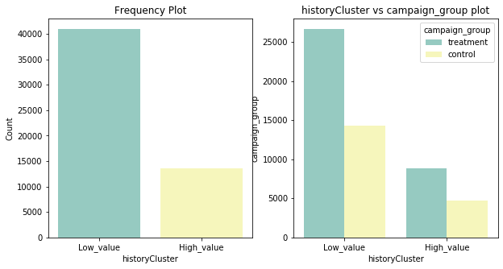

```python
category_plot(df_customer.historyCluster,df_test.campaign_group)
```

En utilisant la fonction sample () de pandas , nous pouvons sélectionner nos groupes de traitement. En supposant que nous aurons 90% de traitement et 10% de groupe contrôle:

```python
df_traitement = df_customer.sample(frac=0.9)
df_control = df_customer[~df_customer.customer_id.isin(df_traitement.customer_id)]
```

Dans cet exemple, nous avons extrait 90% de l'ensemble du groupe et l'avons étiqueté comme traitement . Mais il y a un petit problème qui peut ruiner notre expérience. Si nous avons plusieurs groupes significativement différents dans notre ensemble de données (dans ce cas, de haute valeur et de faible valeur), mieux vaut faire un échantillonnage aléatoire séparément. Sinon, nous ne pouvons pas garantir que le rapport valeur élevée / valeur faible est le même pour le groupe de test et de contrôle. Pour garantir la création correcte des groupes de test et de contrôle, nous devons appliquer le code suivant:

```python
df_traitement_hv = df_customer[df_customer.historyCluster == 'High_value'].sample(frac=0.9)
df_traitement_lv = df_customer[df_customer.historyCluster == 'Low_value'].sample(frac=0.9)

df_traitement = pd.concat([df_traitement_hv,df_traitement_lv],axis=0)
df_control = df_customer[~df_customer.customer_id.isin(df_traitement.customer_id)]
```

```python
df_traitement.historyCluster.value_counts()
```

```
Low_value     36859
High_value    12287
Name: historyCluster, dtype: int64
```

```python
df_control.historyCluster.value_counts()
```

```
Low_value     4095
High_value    1365
Name: historyCluster, dtype: int64
```

```python
df_select = pd.concat([df_traitement,df_control],axis=0)
```

Nous avons faire le test t et sélectionner les groupes de traitement et de contrôle. Mais que faire si nous faisons un test A / B / C ou un test A / B sur plusieurs groupes comme ci-dessus. il faut un **tests ANOVA.**

### **ANOVA unidirectionnelle**

Supposons que nous testons 2+ variantes sur les mêmes groupes (c'est-à-dire 2 offres différentes et aucune offre aux clients à faible valeur et à forte valeur). Nous devons appliquer l'ANOVA unidirectionnelle pour évaluer notre expérience. Commençons par créer notre jeu de données:

```python
df_test_H.shape
```

```
(2939, 4)
```

```python
df_ANOU=df_test_H.copy()
df_ANOU=df_ANOU.reset_index()
df_ANOU['campaign_group'] = 'A'
df_ANOU.loc[df_ANOU.index>=998,'campaign_group'] = 'B'
df_ANOU.loc[df_ANOU.index>=1995,'campaign_group'] = 'C'
```

```python
df_ANOU['campaign_group'].unique()
```

```
array(['A', 'B', 'C'], dtype=object)
```

```python
a_stats = df_ANOU[df_ANOU.campaign_group=='A'].Purchase_count
b_stats = df_ANOU[df_ANOU.campaign_group=='B'].Purchase_count
c_stats = df_ANOU[df_ANOU.campaign_group=='C'].Purchase_count

hist_data = [a_stats, b_stats, c_stats]

group_labels = ['A', 'B','C']

# Create distplot with curve_type set to 'normal'
pyoff.init_notebook_mode(connected=True)
fig = ff.create_distplot(hist_data, group_labels, bin_size=.5,
                         curve_type='normal',show_rug=False)

fig.layout = go.Layout(
        title='Test vs Control Stats',
        plot_bgcolor  = 'rgb(243,243,243)',
        paper_bgcolor  = 'rgb(243,243,243)',
    )


# Plot!
pyoff.iplot(fig)
```

[interactive chart not shown]

Pour évaluer le résultat, nous appliquerons la fonction ci-dessous:

```python
def one_anova_test(a_stats,b_stats,c_stats):
    test_result = stats.f_oneway(a_stats, b_stats, c_stats)
    if test_result[1] < 0.05:
        print('result is significant')
    else:
        print('result is not significant')
```

La logique est similaire à t_test. Si la valeur p est inférieure à 5%, notre test devient significatif:

```python
one_anova_test(a_stats,b_stats,c_stats)
```

```
result is not significant
```

Il n'ya pas une différence significatif entre A B C

### **ANOVA bidirectionnelle**

Disons que nous faisons le même test sur les clients à forte valeur ajoutée et à faible valeur. Dans ce cas, nous devons appliquer l'ANOVA bidirectionnelle. Nous allons recréer notre jeu de données et construire notre méthode d'évaluation:

```python
df_ANOB=df_select.copy()
```

```python
import statsmodels.formula.api as smf
from statsmodels.stats.anova import anova_lm
model = smf.ols(formula='Purchase_count ~ historyCluster + campaign_group ', data=df_ANOB).fit()
aov_table = anova_lm(model, typ=2)
```

En utilisant segment et groupe, le modèle essaie d'atteindre le nombre d' achats. aov_table ci-dessus nous aide à voir si notre expérience est réussie:

```python
print(np.round(aov_table,4))
```

```
                    sum_sq       df         F  PR(>F)
historyCluster      0.0078      1.0    0.0139  0.9061
campaign_group    108.0030      1.0  191.9298  0.0000
Residual        30726.2885  54603.0       NaN     NaN
```

Ceci montre, le campaign_group (treatment; control) affecte de manière significative le nombre d'achats(Purchase_count), mais le historyCluster(Haute ou faible valeur) ne le fait pas car il est de près de 90%, bien supérieur à 5%.

Nous avons sélectionner nos groupes et évaluer les résultats. Mais il manque encore une partie. Pour atteindre une signification statistique, notre taille d'échantillon devrait être suffisante. Voyons comment nous pouvons le calculer.

### **Calcul de la taille de l'échantillon**

Pour calculer la taille d'échantillon requise, nous devons d'abord comprendre deux concepts:

- Taille de l'effet : cela représente l'amplitude de la différence entre les moyennes du groupe traitement et du groupe contrôl. Il s'agit de la variance des moyennes entre les groupes de traitement et de contrôle divisée par l'écart type du contrôle.
- Puissance: il s'agit de la probabilité de trouver une signification statistique dans notre test. Pour calculer la taille de l'échantillon, 0,8 est la valeur courante utilisée.

```python
from statsmodels.stats import power
ss_analysis = power.TTestIndPower()
```

```python
df_hv=df_select.copy()
df_hv = df_hv.query("campaign_group == ['treatment','control'] and historyCluster=='High_value' ")
df_hv=df_hv.drop(['campaign_group'],axis=1).reset_index(drop=True)
df_hv.head()
```

|  | customer_id | historyCluster | Purchase_count |
| --- | --- | --- | --- |
| 0 | 41524 | High_value | 1.0 |
| 1 | 54273 | High_value | 2.0 |
| 2 | 42244 | High_value | 0.0 |
| 3 | 43265 | High_value | 2.0 |
| 4 | 49623 | High_value | 0.0 |

```python
purchase_mean = df_hv.Purchase_count.mean()
purchase_std = df_hv.Purchase_count.std()
```

```python
print(np.round(purchase_mean,4),np.round(purchase_std,4))
```

```
0.5615 0.7525
```

la moyenne des achats (achat_moyen) est de 0,56 et l'écart-type (achat_std) est de 0,75.

Supposons que nous souhaitons augmenter la valeur d'achat à 0,78 dans cette expérience. Nous pouvons calculer la taille de l'effet comme ci-dessous:

```python
effect_size = (0.78 - purchase_mean)/purchase_std
```

Après cela, le calcul de la taille de l'échantillon est assez simple:

```python
alpha = 0.05
power = 0.8
ratio = 1


ss_result = ss_analysis.solve_power(effect_size=effect_size, power=power,alpha=alpha, ratio=ratio , nobs1=None)
print(ss_result)
```

```
187.18565954048435
```

Alpha est le seuil de signification statistique (5%) et notre rapport des tailles des échantillons de traitement et de contrôle est de 1 (égal). Par conséquent, notre taille d'échantillon requise est (sortie de ss_result) 187.

Construisons une fonction pour l'utiliser partout où nous voulons:

```python
def calculate_sample_size(c_data, column_name, target,ratio):
    value_mean = c_data[column_name].mean()
    value_std = c_data[column_name].std()

    value_target = value_mean * target

    effect_size = (value_target - value_mean)/value_std

    power = 0.8
    alpha = 0.05
    ss_result = ss_analysis.solve_power(effect_size=effect_size, power=power,alpha=alpha, ratio=ratio , nobs1=None)
    print(int(ss_result))
```

Pour cette fonction, nous devons fournir notre ensemble de données, le nom_colonne qui représente la valeur (nombre_achats dans notre cas), notre moyenne cible (0,78 était notre cible dans l'exemple précédent) et le ratio.

Dans l'ensemble de données ci-dessus, supposons que nous voulons augmenter la moyenne du nombre d'achats de 5% et que les tailles des deux groupes restent les mêmes:

```python
calculate_sample_size(df_hv, 'Purchase_count', 1.05,1)
```

```
11276
```

Le résultat devient alors 11276.